# MATH9102 Missing Data

Author

Deirdre Lawless

# 1. Install and Load Packages

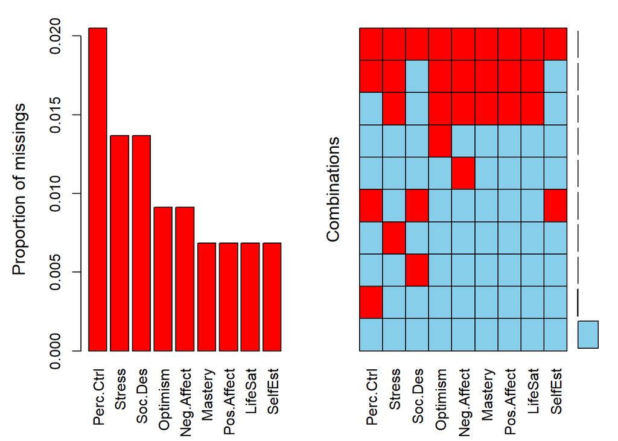

```
 Variables sorted by number of missings:
   Variable       Count
  Perc.Ctrl 0.020501139
     Stress 0.013667426
    Soc.Des 0.013667426
   Optimism 0.009111617
 Neg.Affect 0.009111617
    Mastery 0.006833713
 Pos.Affect 0.006833713
    LifeSat 0.006833713
    SelfEst 0.006833713
```

```r
quiet_library <- function(pkg) {
  suppressMessages(suppressWarnings({
    if (!requireNamespace(pkg, quietly = TRUE)) {
      install.packages(pkg, quiet = TRUE)
    }
    library(pkg, character.only = TRUE)
  }))
}

quiet_library("tidyverse")
quiet_library("VIM") # Visualization and Imputation of Missing Values
quiet_library("naniar") #(naniar short for NA + naniar) - Missing data wrangling plus Little's test
quiet_library("simputation") # For imputing variables

#Amend this to reflect your folder structure
datalocation <- file.path("./")
datapath <- file.path(datalocation,'survey.dat')

#Read in the dataset
sdata <- read.table(datapath)

#Setting the column names to be that used in the dataset but in lowercase to make life a bit easier
colnames(sdata) <- tolower(colnames(sdata))

#Our variables of interest are the nine continuous variables reflecting the total
#for each of our pschological factors measured

#We create a subset with just these variables
varsint<-c("toptim", "tmast", "tposaff", "tnegaff", "tlifesat", "tpstress","tslfest", "tmarlow" , "tpcoiss" )


# create a subset with only variables of interest
sdatasubset <- sdata[varsint]

# rename columns to human-friendly labels - we are restricted with the length we can use
# ask 'vim' to get  missingnes and percenatage of missing ness per variable
# just get human friendly labels
colnames(sdatasubset) <- c("Optimism", "Mastery", "Pos.Affect", "Neg.Affect", "LifeSat", "Stress", "SelfEst", "Soc.Des", "Perc.Ctrl")

#Adjust the margins so that we can display the labels
par(mar = c(10, 4, 4, 2))  # more space at bottom

# run VIM::aggr
res <- summary(VIM::aggr(sdatasubset, sortVar = TRUE, combined = FALSE))$combinations
```

```r
#Get our summary statistics - these are just for us not for publication
summary(sdatasubset)
```

```
    Optimism        Mastery        Pos.Affect      Neg.Affect      LifeSat
 Min.   : 7.00   Min.   : 8.00   Min.   :11.00   Min.   :10.0   Min.   : 5.00
 1st Qu.:19.00   1st Qu.:19.00   1st Qu.:29.00   1st Qu.:14.0   1st Qu.:18.00
 Median :22.00   Median :22.00   Median :34.00   Median :18.0   Median :23.00
 Mean   :22.12   Mean   :21.76   Mean   :33.69   Mean   :19.4   Mean   :22.38
 3rd Qu.:26.00   3rd Qu.:25.00   3rd Qu.:39.00   3rd Qu.:23.0   3rd Qu.:27.00
 Max.   :30.00   Max.   :28.00   Max.   :49.00   Max.   :39.0   Max.   :35.00
 NA's   :4       NA's   :3       NA's   :3       NA's   :4      NA's   :3
     Stress         SelfEst         Soc.Des         Perc.Ctrl
 Min.   :12.00   Min.   :18.00   Min.   : 0.000   Min.   :20.00
 1st Qu.:23.00   1st Qu.:30.00   1st Qu.: 4.000   1st Qu.:53.00
 Median :26.00   Median :35.00   Median : 5.000   Median :62.00
 Mean   :26.73   Mean   :33.53   Mean   : 5.305   Mean   :60.63
 3rd Qu.:31.00   3rd Qu.:38.00   3rd Qu.: 7.000   3rd Qu.:69.00
 Max.   :46.00   Max.   :40.00   Max.   :10.000   Max.   :88.00
 NA's   :6       NA's   :3       NA's   :6        NA's   :9
```

# 2. Visualise the missing data level and pattern

## 2.1 Using functions from VIM

Show number of rows of missing values for each and combinations across variables using VIM::aggr. Get levels of missingness using the aggr function from the VIM package. We summarise and store the results in a variable called res.

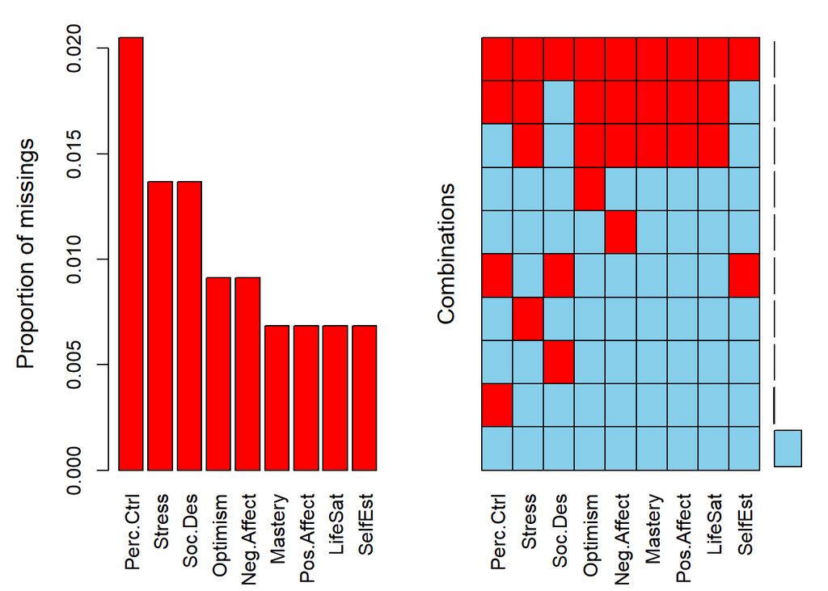

```
 Variables sorted by number of missings:
   Variable       Count
  Perc.Ctrl 0.020501139
     Stress 0.013667426
    Soc.Des 0.013667426
   Optimism 0.009111617
 Neg.Affect 0.009111617
    Mastery 0.006833713
 Pos.Affect 0.006833713
    LifeSat 0.006833713
    SelfEst 0.006833713
```

```r
res<-summary(VIM::aggr(sdatasubset, sortVar=TRUE, combined=FALSE))$combinations
```

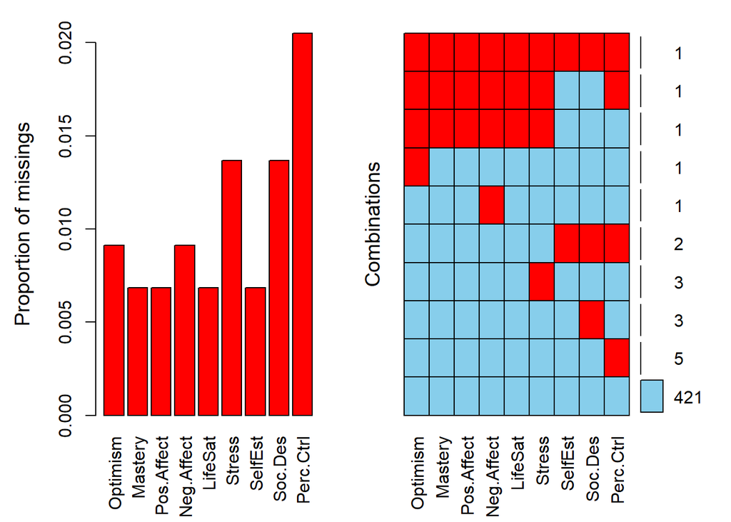

```r
# Show the number of rows missing values for each variable and combinations of variables
#Red is missing, blue is not missing
aggr(sdatasubset, combined = FALSE, numbers = TRUE, prop = c(TRUE, FALSE))
```

Output of the most common combinations using the head function:

```r
head(res[rev(order(res[,2])),])
```

```
        Combinations Count    Percent
1  0:0:0:0:0:0:0:0:0   421 95.8997722
2  0:0:0:0:0:0:0:0:1     5  1.1389522
5  0:0:0:0:0:1:0:0:0     3  0.6833713
3  0:0:0:0:0:0:0:1:0     3  0.6833713
4  0:0:0:0:0:0:1:1:1     2  0.4555809
10 1:1:1:1:1:1:1:1:1     1  0.2277904
```

## 2.2 Summary of whether data is missing or not

Use naniar::vis_miss to create a plot showing whether a variable is missing data and showing the percentage missing:

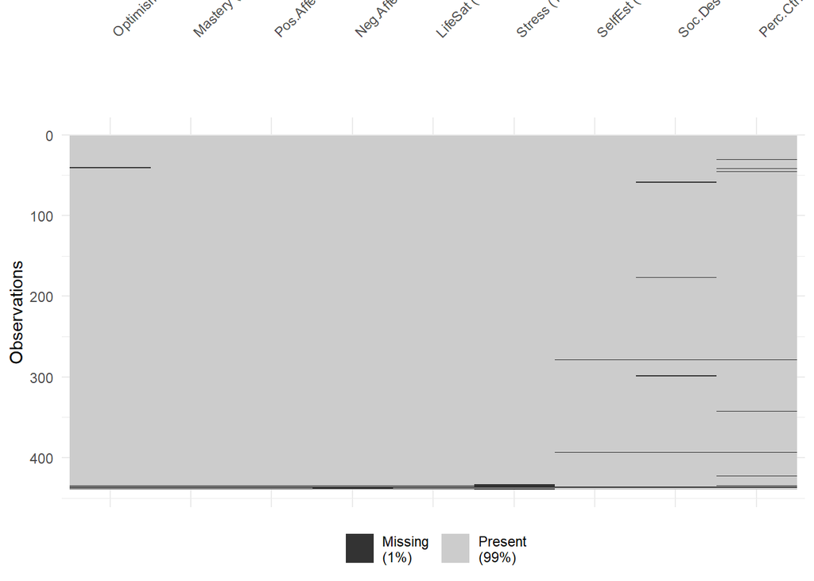

```r
naniar::vis_miss(sdatasubset)
```

This identifies key variables that are missing, but we need to explore the relationship between these variables and others.

Look at the number of cases and the combinations of missingness using naniar::gg_miss_upset:

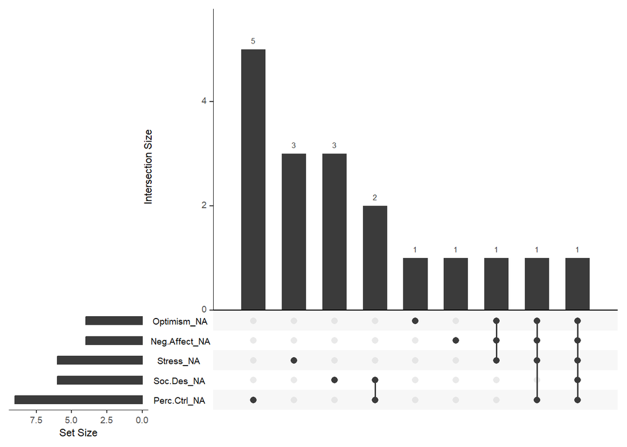

```r
naniar::gg_miss_upset(sdatasubset)
```

We can use ggplot to generate a point plot showing how many missing combinations we have per pair of variables:

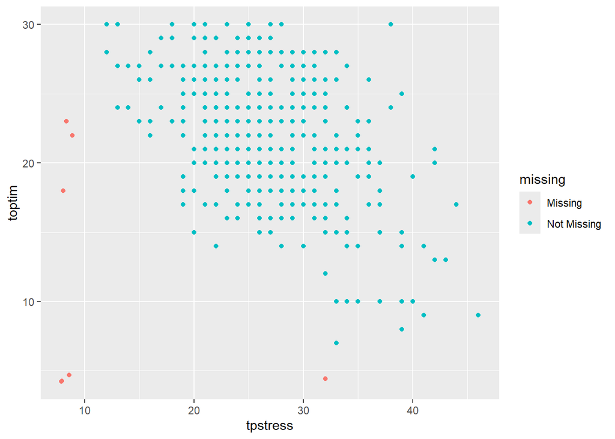

```r
ggplot(sdata,
       aes(x = tpstress,
           y = toptim)) +
  geom_miss_point()
```

## 2.3 Look at patterns by group

We need to include the grouping value as part of the sub-set dataframe we are using We can then look at the pattern using gg_mis_fct from naniar package.

Explore missingness across a factor. In this case by whether respondents have children or not:

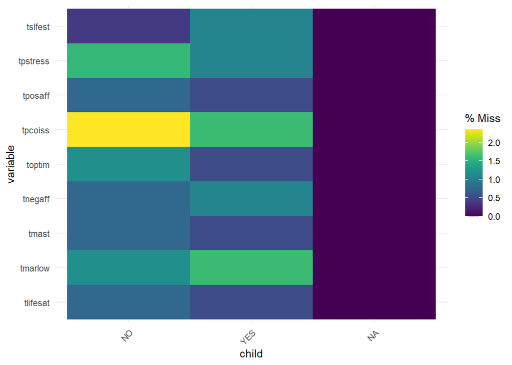

```r
varsintgrp<-c("toptim",     "tmast", "tposaff", "tnegaff", "tlifesat", "tpstress","tslfest", "tmarlow" , "tpcoiss","child" )
# Create a new subset
sdatasubgroup<-sdata[varsintgrp]#create a subset of data with just the variables of interest

naniar::gg_miss_fct(x = sdatasubgroup, fct = child)
```

We can look at a plot by group also for a pair of variables using ggplot:

We can use ggplot to generate a point plot showing how many missing combinations we have per pair of variables for a factor by using facets:

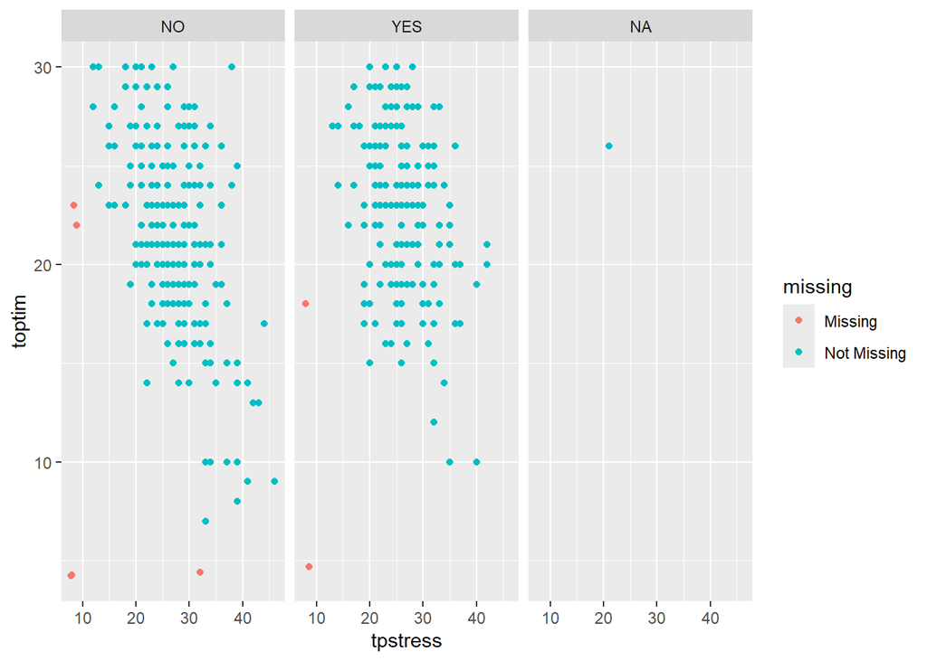

```r
ggplot(sdatasubgroup,
       aes(x = tpstress,
           y = toptim)) +
  geom_miss_point() +
  facet_wrap(~child)
```

You can create tables to look at patterns of missing data in continuous for nominal Or use some of the packages available in https://www.tidyverse.org/

# 3. Mean Substitution Example

You can substitute na values for the variable tpcoiss with the mean of tpcoiss:

```r
sdatasubgroup$tpcoiss[is.na(sdatasubgroup$tpcoiss)] <- mean(sdatasubgroup$tpcoiss, na.rm = TRUE)
```

To look at the number of cases and the combinations of missingness repeat the missingness assessment.

# 4. Imputation Example

You can impute a value for na values for the variable tpstress with the impute_lm function tpstress, the variables used need to make sense. Here we impute tpstress from the values of perception of control and positive affect (we would need to be sure this is sensible for our conceptual framework):

```r
summary(sdatasubgroup$tpstress)
```

```
   Min. 1st Qu.  Median    Mean 3rd Qu.    Max.    NA's
  12.00   23.00   26.00   26.73   31.00   46.00       6
```

```r
sdatasubgroup <- simputation:: impute_lm(sdatasubgroup,tpstress ~ tpcoiss + tposaff)
summary(sdatasubgroup$tpstress)
```

```
   Min. 1st Qu.  Median    Mean 3rd Qu.    Max.    NA's
  12.00   23.00   26.00   26.72   31.00   46.00       3
```

Note: We can see this has resolved only 3 na values - this is because tposaff has na’s so we would need to address that before doing the imputation.

# 5. Test for MCAR

You can use Little’s MCAR test. If the p value is > 0.05 then you fail to reject the null hypothesis that the data are MCAR → consistent with MCAR. If p < 0.05, the data are unlikely to be MCAR (they may be MAR or MNAR). Note: you must have inspect your variables and eliminate MNAR yourself before using this test.

```r
result <- naniar::mcar_test(sdatasubset)

print(result)
```

```
# A tibble: 1 × 4
  statistic    df p.value missing.patterns
      <dbl> <dbl>   <dbl>            <int>
1      66.8    51  0.0676               10
```